# Synthetic Controls in Texas Prison Data

This post uses a synthetic control design to study whether Texas's prison building boom in 1993 resulted in them incarcerating more prisoners than they would have if their rate of prison building had continued as normal. The analysis will roughly follow the book [Causal Inference: The Mixtable](https://mixtape.scunning.com/), but we'll use a Bayesian workflow here instead of traditional hypothesis testing.

We'll express Texas's incarceration rates over time as a mixture of those of other states. Then, we'll use this mixture of other states to construct a "synthetic" counterfactual Texas which, like the states in the mixture, didn't have a prison building boom in '93. We can compare the difference between the true and synthetic Texas over time.

```python
import os
os.environ["JAX_PLATFORMS"] = "cpu"
import numpyro
numpyro.set_host_device_count(4)
import pyro_util
import pandas as pd
import numpy as np
import numpyro.distributions as dist
import arviz as az
import xarray as xr
import seaborn as sns
import matplotlib.pyplot as plt
import jax.numpy as jnp
```

```python
texas = pd.read_stata("https://github.com/scunning1975/mixtape/raw/master/texas.dta")
```

Our endogenous variable $y$ will be the black male incarceration rate per 100k people.

```python
texas['incarceration_rate'] = texas.bmprison / (texas.bmpop / 100_000)
```

Looking at the data shows a pretty sizeable increase in Texas's incarceration rate after '93 compared to other states, which lends credence to the hypothesis. Note that DC is included as a 51st state.

```python
years = pd.unique(texas.year)
```

```python
all_rates = np.reshape(texas[texas.state != "Texas"].sort_values(
    ["state", "year"]).incarceration_rate.values, (50, -1))
```

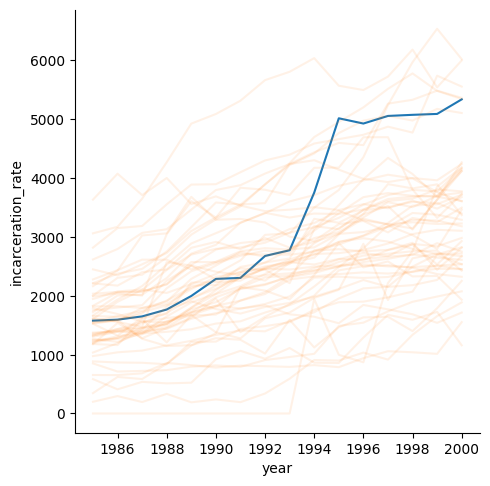

```python
sns.relplot(texas[texas.state == "Texas"], x="year", y="incarceration_rate", kind="line");
for r in all_rates:
    plt.plot(years, r, color="C1", alpha=0.1)
```

We'll chose our mixture weights to combine other states into a synthetic Texas with matching poverty, alcoholism and incarceration rates during the period before 1993. $X$ will be a $S \times T \times K$ matrix where $S$ is the number of states (other than Texas), $T$ is the number of observed pre-treatment years and $K$ is the number of covariates to be matched.

```python
def synth_control(y, predictive=False):
    w = numpyro.sample("w", dist.Dirichlet(jnp.ones(50) / 10))
    with numpyro.plate("covariate", X.shape[-1]):
        sigma = numpyro.sample("sigma", dist.Exponential(1 / stds))
        with numpyro.plate("pre_treatment_year", X.shape[-2]):
            numpyro.sample("pre_treatment_obs",
                           dist.Normal(loc=(X.T @ w).T, scale=sigma), obs=None if predictive else y)
    with numpyro.plate("all_years`", test_X.shape[-1]):
        yhat = numpyro.deterministic("yhat", (w @ test_X))
```

To compute $X$, we can use the function `to_tensor` we defined in the previous post.

```python
covariates = ["poverty", 'incarceration_rate', 'alcohol']
```

```python
X, X_ix = pyro_util.to_tensor(texas[(texas.state != "Texas") & (texas.year < 1993)], covariates, ["state", "year"])
```

```python
states = X_ix.levels[0]
```

We can use the same function to compute the covariate values our synthetic Texas should obtain for the pre-treatment years.

```python
y, _ = pyro_util.to_tensor(texas[(texas.state == "Texas") & (texas.year < 1993)], covariates, ["year"])
```

```python
test_X = pyro_util.to_tensor(texas[texas.state != "Texas"], ["incarceration_rate"],
                       ["state", "year"])[0].squeeze()
```

We'll use an uninformative prior for the noise.

```python
stds = 2.5 * jnp.array(texas.loc[texas.year < 1993, ["year", *covariates]
                 ].groupby("year").std().mean().values)
```

Fitting the model lets us plot the incarceration rate for our counterfactual "synthetic" version of Texas. This plot suggests that if the prison building boom had not occurred, incarceration rates would have risen much more slowly.

```python
mcmc = pyro_util.fit_nuts(synth_control, y)
```

```python
samples = mcmc.get_samples()
```

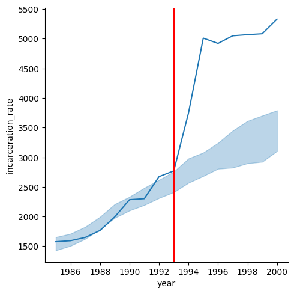

```python
sns.relplot(texas[texas.state == "Texas"], x="year", y="incarceration_rate", kind="line");
az.plot_hdi(years, samples['yhat'][None,:,:], color='C0', smooth=False, fill_kwargs={"alpha": 0.3})
plt.axvline(x=1993, c='red');
```

```python
mean_ws = samples['w'].mean(axis=0)
std_ws = samples['w'].std(axis=0)
mean_ixs = np.argsort(mean_ws)[-10:]
list(zip(states[mean_ixs], mean_ws[mean_ixs]))
```

```
[('Oklahoma', Array(0.01886202, dtype=float32)),
 ('District of Columbia', Array(0.01958421, dtype=float32)),
 ('Illinois', Array(0.02461748, dtype=float32)),
 ('Virginia', Array(0.02528147, dtype=float32)),
 ('California', Array(0.03051868, dtype=float32)),
 ('Mississippi', Array(0.03408278, dtype=float32)),
 ('Arizona', Array(0.03647023, dtype=float32)),
 ('Colorado', Array(0.03801526, dtype=float32)),
 ('New Mexico', Array(0.07698458, dtype=float32)),
 ('Louisiana', Array(0.2909835, dtype=float32))]
```

This model describes the underlying dynamics reasonably well; the posterior predictive checks look good.

```python
texas_results = pyro_util.from_numpyro(texas, synth_control, mcmc, y)
```

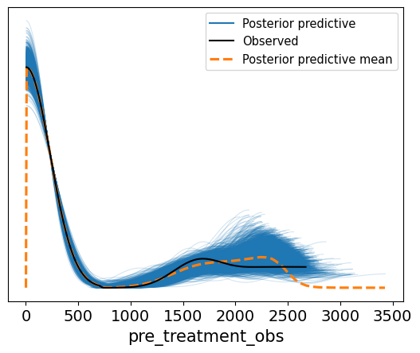

```python
az.plot_ppc(texas_results, var_names='pre_treatment_obs');
```

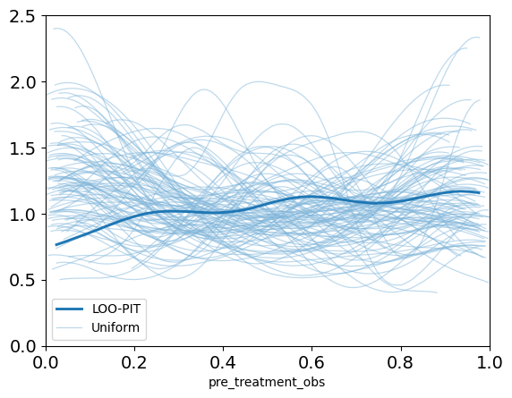

```python
az.plot_loo_pit(texas_results, y="pre_treatment_obs")
```